# R Notebook

Notes - Link to the data I downloaded from PG Open Data https://data.princegeorgescountymd.gov/Public-Safety/Crime-Incidents-February-2017-to-5th-July-2023/wb4e-w4nf

library

```r
library(tidyverse)
library(janitor)
library(lubridate)
#install.packages('tidygeocoder')
library(tidygeocoder)
#install.packages("curl")
library(curl)
library(ggplot2)
library(ggrepel)
```

loading data

```r
pg_county_crime_old <-  read.csv("data/pg_county_crime.csv")
moco_data <- read_csv("data/test_data.csv")
pg_county_crime_new <-  read.csv("data/pg_county_crime_new.csv")
```

cleaning data

```r
pg_county_crime_old <- pg_county_crime_old %>%
  clean_names()

pg_county_crime_new <- pg_county_crime_new %>%
  clean_names()
```

making the dates appropreate

```r
#extracting the year column and making the date the correct format
pg_county_crime_old <- pg_county_crime_old %>%
 mutate(date = as.Date(date, "%m/%d/%Y"),
        year = year(date),
         month = month(date)) %>%
  filter(date <= "2023-07-01")

pg_county_crime_new <- pg_county_crime_new %>%
  mutate(date = as.Date(date, "%m/%d/%Y"),
        year = year(date),
         month = month(date))


# Renaming the crime column to be easier to work with
pg_county_crime_old <-  pg_county_crime_old %>%
  rename(crime_type = clearance_code_inc_type)

pg_county_crime_new <- pg_county_crime_new %>%
   rename(crime_type = clearance_code_inc_type)
```

```r
pg_county_crime_old %>%
  distinct(crime_type)

pg_county_crime_new %>%
  distinct(crime_type)
```

```r
pg_county_crime_old <- pg_county_crime_old %>%
  filter(year >= 2019)

#pg county_crime_new from July 5 - Oct. 10

#binding

total_pg_county_data <- bind_rows(pg_county_crime_old, pg_county_crime_new )
```

—– Exploratory data section ——-

What I want to accomplish here? - I want to see monthly data that goes back a few years for stolen, auto. DONE

filtering for AUTO, STOLEN

```r
pg_stolen_auto <- total_pg_county_data %>%
  filter(crime_type == "AUTO, STOLEN" | crime_type == "AUTO, STOLEN & RECOVERED" )
```

Time elements

[output not shown]

Confirms a steady increase from 2020 to 2023. Showing on a graph to visualize the increase.

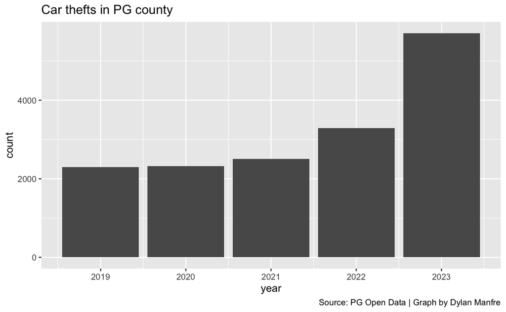

```r
ggplot() +
  geom_bar(
    data=pg_yearly_data,
    aes(x=year, weight=`stolen_auto`))+
  labs(title = "Car thefts in PG county",
       caption =  "Source: PG Open Data | Graph by Dylan Manfre")
```

monthly totals

```r
pg_stolen %>%
  group_by(month, year) %>%
  summarize(autos_stolen = n()) %>%
  mutate(month = month(month, label = TRUE)) %>%
  pivot_wider(names_from = year, values_from = autos_stolen)
```

| month | 2019 | 2020 | 2021 | 2022 |
| --- | --- | --- | --- | --- |
| Jan | 200 | 239 | 188 | 221 |
| Feb | 167 | 185 | 159 | 164 |
| Mar | 183 | 170 | 189 | 224 |
| Apr | 162 | 164 | 224 | 187 |
| May | 208 | 182 | 256 | 251 |
| Jun | 187 | 208 | 231 | 230 |
| Jul | 193 | 211 | 190 | 209 |
| Aug | 177 | 195 | 241 | 300 |
| Sep | 224 | 154 | 249 | 275 |
| Oct | 186 | 218 | 226 | 375 |

[output cut: 2 more lines]

```r
pg_stolen_auto %>%
  group_by(year, crime_type) %>%
  summarize(count = n()) %>%
  mutate(perc = (count / sum(count)) * 100)
```

[output not shown]

yearly total for stolen and recovered

```r
pg_stolen_recovered_years <- pg_stolen_recovered_only %>%
  group_by(year) %>%
  summarize(stolen_recovered = n()) %>%   arrange(desc(stolen_recovered))

pg_stolen_recovered_months <- pg_stolen_recovered_only %>%
  group_by(month, year) %>%
  summarize(stolen_recovered = n()) %>%
   mutate(month = month(month, label = TRUE)) %>%
  arrange(desc(stolen_recovered))
#joining pg_stolen_recovered_months with pg_month_total

combined_pg_monthly <- inner_join(pg_stolen_recovered_months, pg_month_total, by=c("month", "year"))

combined_pg_monthly <- combined_pg_monthly %>%
  mutate(grand_total = stolen_recovered + autos_stolen)

write_csv(combined_pg_monthly, "data/combined_pg_monthly.csv")
```

```r
#join pg_stolen_recovered_years and #pg_yearly_data

combined_pg_years <- inner_join(pg_stolen_recovered_years, pg_yearly_data, by=c("year")) %>%
  select(-perc)

combined_pg_years <- combined_pg_years %>%
  mutate(grand_total = stolen_auto + stolen_recovered)

write_csv(combined_pg_years, "data/combined_pg_years.csv") #use this dataset for a stacked bar chart.
```

test <- stolen_auto %>% filter(incident_case_id == “PP21062600000290”)

—–Reverse geocoding section for PG County —–

# Number of rows you want in each subset

subset_size <- 1468

# Split the data into eight subsets

subset1 <- stolen_auto[1:subset_size,] subset2 <- stolen_auto[(subset_size + 1):(2 * subset_size), ] subset3 <- stolen_auto[(2 * subset_size + 1):(3 * subset_size), ] subset4 <- stolen_auto[(3 * subset_size + 1):(4 * subset_size), ] subset5 <- stolen_auto[(4 * subset_size + 1):(5 * subset_size), ] subset6 <- stolen_auto[(5 * subset_size + 1):(6 * subset_size), ] subset7 <- stolen_auto[(6 * subset_size + 1):(7 * subset_size), ] subset8 <- stolen_auto[(7 * subset_size + 1):(8 * subset_size), ]

reverse geocoding

#subset2 <- subset2 %>% reverse_geocode(lat = latitude, long = longitude, method = ‘osm’, address = street_address, full_results = TRUE)

MoCo Data

```r
# cleaning

moco_data <- moco_data %>%
   clean_names() %>%
  separate(start_date_time, c('start_date', 'start_time'), sep=' ', extra='merge') %>%
  mutate(start_date = as.Date(start_date, format = "%m/%d/%Y"),
          year = year(start_date),
         month = month(start_date)) %>%
  filter(year >= 2019) %>%
filter(crime_name2 == "Motor Vehicle Theft") %>%
  rename(crime_name = crime_name2)

moco_data <- moco_data %>%
  mutate(city = case_when(
    city == "SILVE SPRING" ~ "SILVER SPRING",
    city == "BEHTESDA" ~ "BETHESDA",
    city == "SILVERS SPRING" ~ "SILVER SPRING",
    city == "GAIHTERSBURG" ~ "GAITHERSBUG",
    city == "BETHEDA" ~ "BETHESDA",
    city == "BARNSVILLE" ~ "BARNESVILLE",
    city == "BEALSVILLE" ~ "BEALLSVILLE",
    city == "CLAEKSBURG" ~ "CLARKSBURG",
    city == "GAIHTERSBURG" ~ "GAITHERSBURG",
    city == "GAITHERBURG" ~ "GAITHERSBURG",
    city == "GAITHERSBUG" ~ "GAITHERSBURG",
    city == "GAUTHERSBURG" ~ "GAITHERSBURG",
    city == "GAITHERSBUG" ~ "GAITHERSBURG",
    city == "GRMANTOWN" ~ "GERMANTOWN",
    city == "KENSTINGTON" ~ "KENSINGTON",
    city == "MT AIRY" ~ "MOUNT AIRY",
    city == "TACOMA PARK" ~ "TAKOMA PARK",
    city == "WEHATON" ~ "WHEATON",
    TRUE ~ city
  ))

moco_cities <- moco_data %>%
  filter(year == 2023) %>%
  group_by(city) %>%
  summarize(count = n()) %>%
  arrange(desc(count))
```

———— EXPLORATORY DATA FOR MOCO ———–

Iso 2023

```r
moco_2023 <- moco_data %>%
  filter(year == "2023", crime_name == "Motor Vehicle Theft")

#exporting 2023

write_csv(moco_2023, "data/moco_2023.csv")
```

All moco car thefts

```r
moco_car_thefts <- moco_data %>%
  filter(crime_name == "Motor Vehicle Theft")

write_csv(moco_car_thefts, "data/moco_car_thefts.csv")

View(moco_car_thefts)
```

Quick visual of the yearly thefts

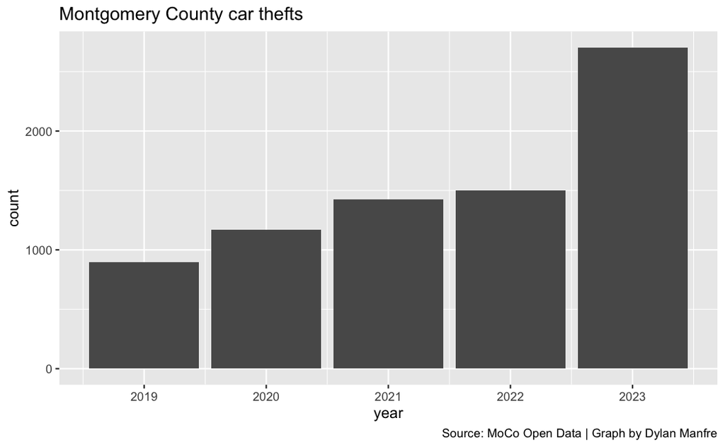

```r
moco_yearly <- moco_car_thefts %>%
  group_by(year) %>%
  summarize(count = n()) %>%
  mutate(perc = count/sum(count)*100)

ggplot() +
  geom_bar(
    data=moco_yearly,
    aes(x=year, weight=`count`))+
  labs(title = "Montgomery County car thefts",
       caption =  "Source: MoCo Open Data | Graph by Dylan Manfre")
```

```r
write_csv(moco_yearly, "data/moco_yearly.csv")
```

```r
moco_theft_places <- moco_car_thefts %>%
  group_by(place) %>%
  summarize(count = n()) %>%
  mutate(perc = count/sum(count)*100) %>%
  arrange(desc(count))

write_csv(moco_theft_places, "data/moco_theft_places.csv")


#2023 only

moco_car_thefts %>%
  filter(year == 2023) %>%
  group_by(place) %>%
  summarize(count = n()) %>%
  mutate(perc = count/sum(count)*100) %>%
  arrange(desc(count))
```

| place | count | perc |
| --- | --- | --- |
| Parking Lot - Residential | 1095 | 40.49556213 |
| Street - Residential | 596 | 22.04142012 |
| Parking Garage - Residential | 146 | 5.39940828 |
| Residence - Driveway | 142 | 5.25147929 |
| Parking Lot - Commercial | 133 | 4.91863905 |
| Street - In vehicle | 61 | 2.25591716 |
| Parking Garage - County | 50 | 1.84911243 |
| Residence - Apartment/Condo | 50 | 1.84911243 |
| Street - Other | 50 | 1.84911243 |
| Street - Commercial | 49 | 1.81213018 |

[output cut: 41 more lines]

```r
NA
```

Moco monthly totals

```r
 moco_monthly <- moco_car_thefts %>%
  filter(year == "2022" | year == "2023") %>%
  group_by(month, year) %>%
  summarize(count = n()) %>%
  mutate(
    month_year = paste0(format(as.Date(paste(year, month, "01"), "%Y %m %d"), "%b-%y")))
write_csv(moco_monthly, "data/moco_monthly.csv")


#pivot_wider(names_from = year, values_from = count, values_fill = 0)
```